# Analyse descriptive

Groupe 25

2024-01-16

# CHARGEMENT DES DONNEES

```r
rm(list=ls())

AMR <- read_excel('donnees/donnees_AMR.xlsx')
str(AMR)
```

```
## tibble [1,083 × 7] (S3: tbl_df/tbl/data.frame)
##  $ dispositif  : chr [1:1083] "LNR" "LNR" "LNR" "LNR" ...
##  $ annee       : num [1:1083] 2014 2016 2016 2016 2016 ...
##  $ population  : chr [1:1083] "volaille-abattoir" "volaille-abattoir" "volaille-abattoir" "volaille-abattoir" ...
##  $ famille     : chr [1:1083] "animale" "animale" "animale" "animale" ...
##  $ region      : chr [1:1083] "Nationale" "Bretagne" "Nouvelle-Aquitaine" "Pays de la Loire" ...
##  $ valeur AMR  : num [1:1083] 25.3 17.8 36.1 35.2 28.1 21.1 25.7 44.8 35 28.8 ...
##  $ effectif AMR: num [1:1083] 466 163 36 91 381 175 35 116 434 146 ...
```

```r
summary(AMR)
```

```
##   dispositif            annee       population          famille
##  Length:1083        Min.   :2012   Length:1083        Length:1083
##  Class :character   1st Qu.:2015   Class :character   Class :character
##  Mode  :character   Median :2018   Mode  :character   Mode  :character
##                     Mean   :2017
##                     3rd Qu.:2020
##                     Max.   :2021
##     region            valeur AMR     effectif AMR
##  Length:1083        Min.   : 1.30   Min.   :    29
##  Class :character   1st Qu.:36.43   1st Qu.:    77
##  Mode  :character   Median :48.20   Median :   218
##                     Mean   :45.61   Mean   :  6292
##                     3rd Qu.:57.10   3rd Qu.:  1299
##                     Max.   :87.80   Max.   :539721
```

```r
# Séparation des deux cas d'étude (animal et humain) version Florine
AMR_humaine <- AMR[which(AMR$famille=='humaine'),]
AMR_animale <- AMR[which(AMR$famille=='animale'),]

# Séparation des deux cas d'étude (animal et humain) version Maël
AMR_animale <- AMR %>%
  filter(famille == "animale")
AMR_humaine <- AMR %>%
  filter(famille == "humaine")

# Récupération des données nationales uniquement
AMR_animale_fr <- AMR_animale[which(AMR_animale$region=='Nationale'),]
AMR_humaine_fr <- AMR_humaine[which(AMR_humaine$region=='Nationale'),]

# Création d'une indicatrice selon si la population provient d'un abattoir (1) ou non (0)
AMR_animale_fr$abattoir <- as.integer(grepl("abattoir", AMR_animale_fr$population, ignore.case = TRUE))
```

Attention ! On ne possède pas de données nationales pour les populations suivantes : Ovin, Caprin, volaille –> faire une moyenne avec les régions disponibles ? Problème : trouver comment les valeurs nationales ont-été trouvées.

# VARIATIONS INTER-GROUPES

```r
# Pour les animaux, on regarde la moyenne de l'AMR pour chaque population
moyenne_AMR <- AMR_animale_fr %>%
  group_by(population, famille) %>%
  summarize(moyenne_AMR = mean(`valeur AMR`))
# On regarde la variance inter-groupe (et l'écart-type car plus parlant)
AMR_animale_fr %>% summarize(ecart_type_AMR = sd(`valeur AMR`))
```

```
## # A tibble: 1 × 1
##   ecart_type_AMR
##            <dbl>
## 1           17.9
```

```r
AMR_animale_fr   %>%
  group_by(population, famille) %>%
  summarize(
    moyenne_AMR = mean(`valeur AMR`),
    .groups = 'drop'
  ) %>%
  ungroup() %>%
  summarize(
    SSB = sum((moyenne_AMR - mean(moyenne_AMR))^2 * n())
  )
```

```
## # A tibble: 1 × 1
##      SSB
##    <dbl>
## 1 49299.
```

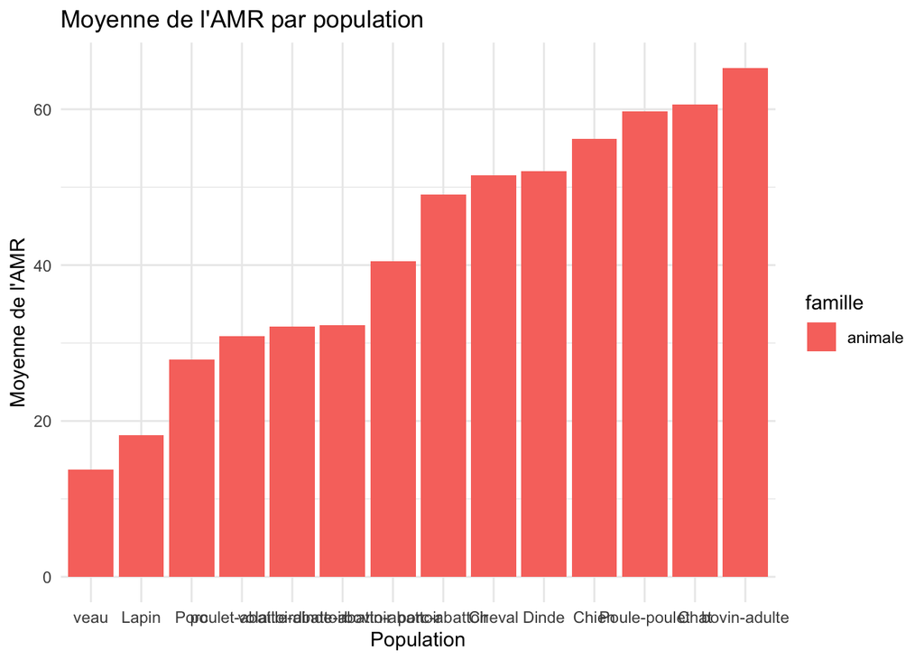

```r
# Plot des moyennes (agrandir le graphique pour la lisibilité)
ggplot(moyenne_AMR, aes(x = reorder(population, moyenne_AMR), y = moyenne_AMR, fill = famille)) +
  geom_bar(stat = "identity", position = "dodge") +
  labs(title = "Moyenne de l'AMR par population",
       x = "Population",
       y = "Moyenne de l'AMR") +
  theme_minimal()
```

Variation inter-groupes plutôt importante chez les animaux : de 13,80 pour la population veau, à 65,30 pour la population bovin-adulte (Remarque : étonnant que les 2 soient aussi éloignés…) et écart-type de 17.86663. Variance inter-groupe de 49298.88. Similarité entre les populations possédant des moyennes proches ? (chat et chien qui vivent plus en solitaires –> moyenne parmis les plus élevées) Un peu trop abstrait car c’est à nous de déterminer les populations qui vivent plus en solitaire ou en groupe –> pas objectif d’un pdv statistique.

Pour poursuivre l’analyse : La région influe-t-elle sur la moyenne et la variabilité ? (Si oui, on peut faire une carte de la sensibilité en France)

# COMPARAISON DES POPULATIONS EN ABATTOIR OU NON

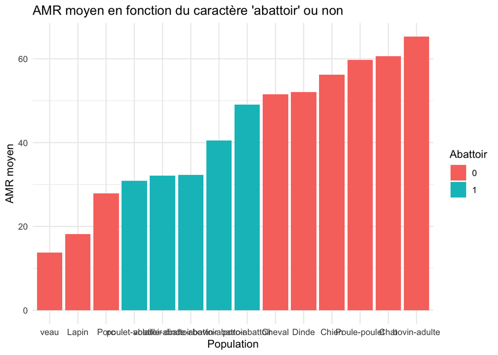

```r
# Création d'une indicatrice selon si la population provient d'un abattoir (1) ou non (0)
moyenne_AMR$abattoir <- as.integer(grepl("abattoir", moyenne_AMR$population, ignore.case = TRUE))

# Graphique
ggplot(moyenne_AMR, aes(x = reorder(population, moyenne_AMR), y = moyenne_AMR, fill = factor(abattoir))) +
  geom_bar(stat = "identity", position = "dodge") +
  labs(title = "AMR moyen en fonction du caractère 'abattoir' ou non",
       x = "Population",
       y = "AMR moyen",
       fill = "Abattoir") +
  theme_minimal()
```

Les populations en abattoir possèdent des moyennes sensiblement différentes des autres populations. Dans 4 cas sur 5, la moyenne de l’AMR est plus faible pour les populations en abattoir (sauf pour le porc, dû au fait que les porcs en abattoir viennent tous de Bretagne –> sensibilité plus élevées en Bretagne ?), ce qui s’explique par la proximité entre les individus –> meilleur transmission de bactéries –> meilleur résistance (sensibilité plus faible)

Pour poursuivre l’analyse : Existe-t-il un biais dû à la région (abattoir dans des régions ou l’AMR est plus faible initialement ?) ? –> regarder la moyenne de Bretagne par rapport aux moyennes des autres régions. Attention ! Comparer sur les mêmes populations (sinon biais)

# SIGNIFICATIVITE

```r
# Regression linéaire
modele_regression <- lm(`valeur AMR` ~ population, data = AMR_animale_fr)
summary(modele_regression)
```

```
##
## Call:
## lm(formula = `valeur AMR` ~ population, data = AMR_animale_fr)
##
## Residuals:
##     Min      1Q  Median      3Q     Max
## -12.567  -2.373   0.150   3.349  12.133
##
## Coefficients:
##                             Estimate Std. Error t value Pr(>|t|)
## (Intercept)                   40.475      2.716  14.902  < 2e-16 ***
## populationbovin-adulte        24.825      3.214   7.725 8.85e-12 ***
## populationChat                20.115      3.214   6.259 9.72e-09 ***
## populationCheval              11.035      3.214   3.434 0.000868 ***
## populationChien               15.715      3.214   4.890 3.86e-06 ***
## populationDinde               11.545      3.214   3.592 0.000510 ***
## populationdinde-abattoir      -8.225      3.841  -2.141 0.034683 *
## populationLapin              -22.265      3.214  -6.928 4.21e-10 ***
## populationPorc               -12.565      3.214  -3.910 0.000168 ***
## populationporc-abattoir        8.592      3.507   2.450 0.016015 *
## populationPoule-poulet        19.215      3.214   5.979 3.49e-08 ***
## populationpoulet-abattoir     -9.608      3.507  -2.740 0.007274 **
## populationveau               -26.675      3.214  -8.300 5.12e-13 ***
## populationvolaille-abattoir   -8.325      3.841  -2.167 0.032587 *
## ---
## Signif. codes:  0 '***' 0.001 '**' 0.01 '*' 0.05 '.' 0.1 ' ' 1
##
## Residual standard error: 5.432 on 100 degrees of freedom
## Multiple R-squared:  0.9182, Adjusted R-squared:  0.9076
## F-statistic: 86.34 on 13 and 100 DF,  p-value: < 2.2e-16
```

Pour valider l’intéprétation des différentes populations, on effectue une regression linéaire sur celles-ci.

# ANALYSE DES REGIONS

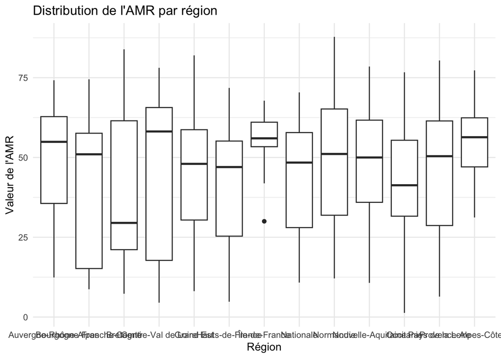

```r
moyenne_par_region <- AMR_animale %>%
  group_by(region) %>%
  summarize(moyenne_AMR = mean(`valeur AMR`), .groups = 'drop')

ggplot(AMR_animale, aes(x = region, y = `valeur AMR`)) +
  geom_boxplot() +
  labs(title = "Distribution de l'AMR par région",
       x = "Région",
       y = "Valeur de l'AMR") +
  theme_minimal()
```

```r
moyenne_par_region_population <- AMR_animale %>%
  group_by(region, population) %>%
  summarize(moyenne_AMR = mean(`valeur AMR`), .groups = 'drop')

modele_anova <- aov(moyenne_AMR ~ region + population, data = moyenne_par_region_population)
summary(modele_anova)
```

```
##             Df Sum Sq Mean Sq F value Pr(>F)
## region      12   1523   126.9   2.198 0.0192 *
## population  16  29082  1817.6  31.475 <2e-16 ***
## Residuals   81   4678    57.7
## ---
## Signif. codes:  0 '***' 0.001 '**' 0.01 '*' 0.05 '.' 0.1 ' ' 1
```

```r
# je n'arrive pas à réaliser l'analyse que je veux :()
```

# VARIATIONS INTRA-GROUPES

```r
AMR_animale_fr %>%
  group_by(population, famille) %>%
  summarize(
    variance_intragroupe = sum((`valeur AMR` - mean(`valeur AMR`))^2),
    .groups = 'drop'
  )
```

```
## # A tibble: 14 × 3
##    population        famille variance_intragroupe
##    <chr>             <chr>                  <dbl>
##  1 Chat              animale               275.
##  2 Cheval            animale               322.
##  3 Chien             animale               317.
##  4 Dinde             animale               296.
##  5 Lapin             animale               174.
##  6 Porc              animale                53.4
##  7 Poule-poulet      animale               323.
##  8 bovin-abattoir    animale               149.
##  9 bovin-adulte      animale               254.
## 10 dinde-abattoir    animale               183.
## 11 porc-abattoir     animale               314.
## 12 poulet-abattoir   animale               148.
## 13 veau              animale                 6.12
## 14 volaille-abattoir animale               136.
```

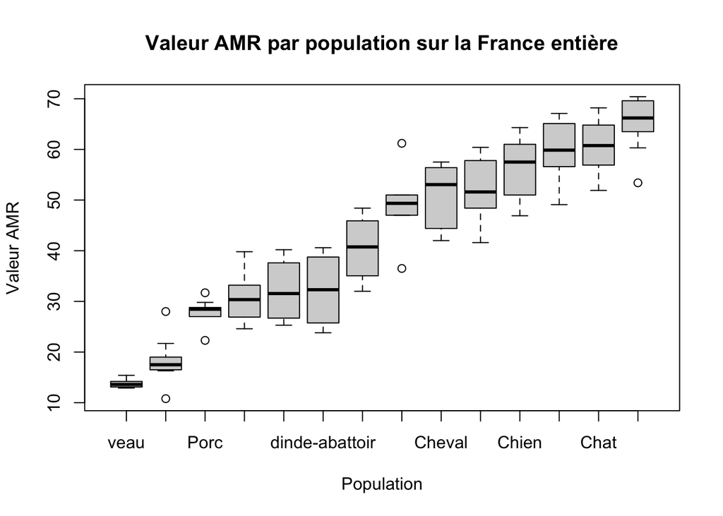

```r
# Boxplot pour représenter la variation intra-groupe
boxplot(`valeur AMR` ~ reorder(population, `valeur AMR`), data = AMR_animale_fr,
        main = "Valeur AMR par population sur la France entière",
        ylab = "Valeur AMR",
        xlab = "Population")
```

Variance intra-groupe volatile en fonction des populations –> d’où vient cette variabilité ? Est-ce une tendance par années (croissante/décroissante) ou un phénomène aléatoire ? (réponse plus bas, spoiler c’est pas une tendance)

Pour poursuivre l’analyse : Similarités entre les population possédant des variances intra proches ? (par exemple les populations en abattoir vs les autres)

# EVOLUTION DE L’AMR EN FONCTION DES ANNEES

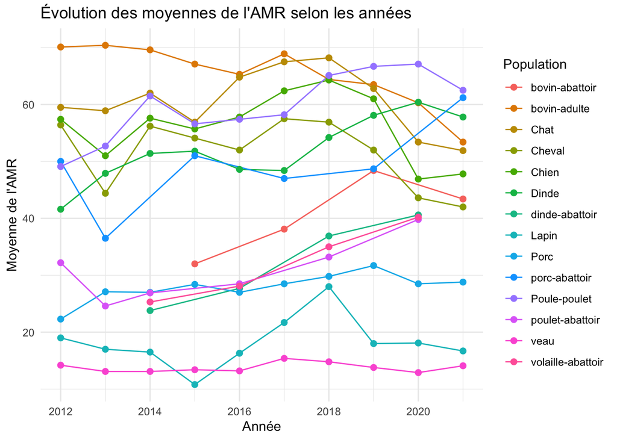

```r
# Graphique général (peu lisible)
ggplot(AMR_animale_fr, aes(x = annee, y = `valeur AMR`, group = population, color = population)) +
  geom_line(stat = "summary", fun = "mean") +
  geom_point(stat = "summary", fun = "mean", size = 2) +
  labs(title = "Évolution des moyennes de l'AMR selon les années",
       x = "Année",
       y = "Moyenne de l'AMR",
       color = "Population") +
  theme_minimal()
```

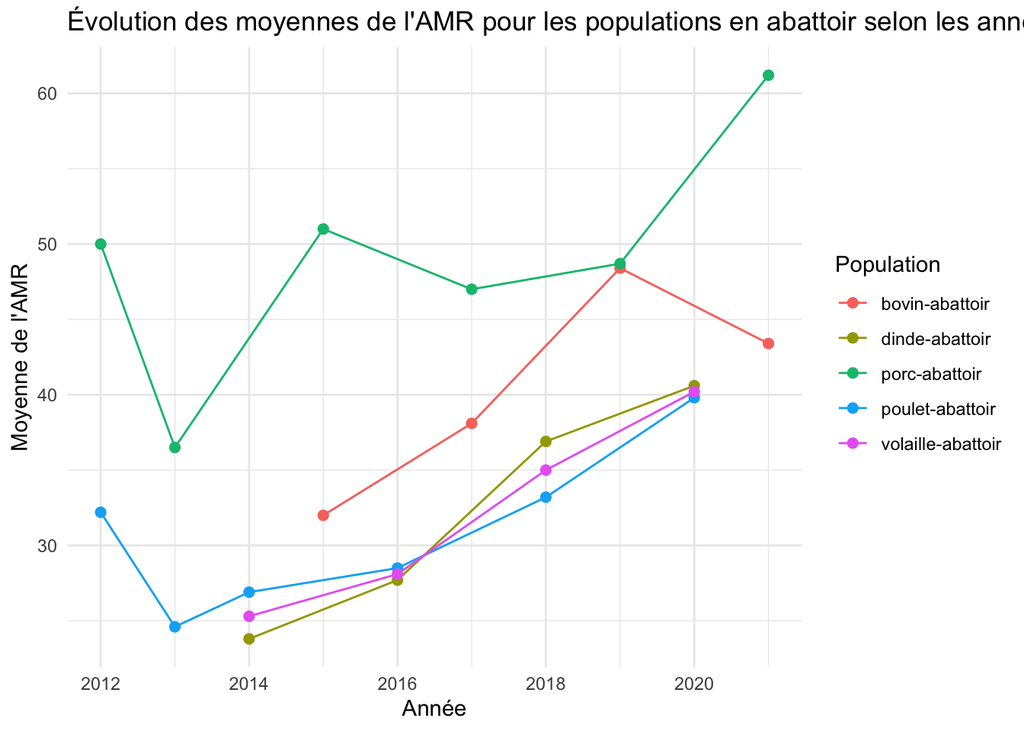

```r
# On filtre les données pour inclure uniquement les populations en abattoir ou non
AMR_animale_fr_abattoir <- AMR_animale_fr %>%
  filter(grepl("abattoir", population, ignore.case = TRUE))

AMR_animale_fr_horsabattoir <- AMR_animale_fr %>%
  filter(!grepl("abattoir", population, ignore.case = TRUE))

# Graphique abattoir
ggplot(AMR_animale_fr_abattoir, aes(x = annee, y = `valeur AMR`, group = population, color = population)) +
  geom_line(stat = "summary", fun = "mean") +
  geom_point(stat = "summary", fun = "mean", size = 2) +
  labs(title = "Évolution des moyennes de l'AMR pour les populations en abattoir selon les années",
       x = "Année",
       y = "Moyenne de l'AMR",
       color = "Population") +
  theme_minimal()
```

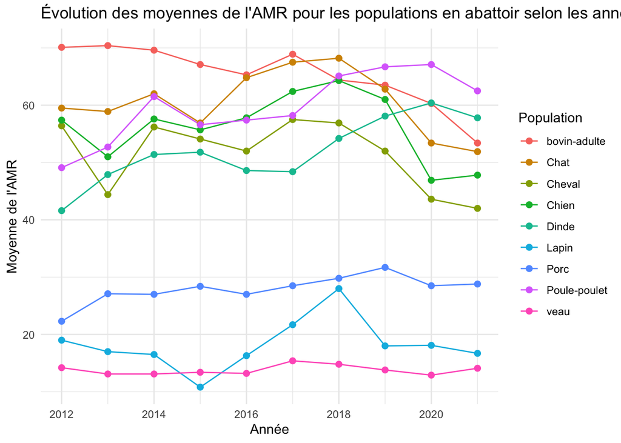

```r
# Graphique hors abattoir
ggplot(AMR_animale_fr_horsabattoir, aes(x = annee, y = `valeur AMR`, group = population, color = population)) +
  geom_line(stat = "summary", fun = "mean") +
  geom_point(stat = "summary", fun = "mean", size = 2) +
  labs(title = "Évolution des moyennes de l'AMR pour les populations en abattoir selon les années",
       x = "Année",
       y = "Moyenne de l'AMR",
       color = "Population") +
  theme_minimal()
```

On note une tendance croissante de l’AMR en fonction des années pour les populations en abattoir. Pour les autres populations, la tendance est beaucoup moins claire –> la variation intra n’est donc pas dûe à une tendance croissante (ou décroissante) mais à un autre facteur !

# VISUALISATION DE DONNEES (HUMAIN)

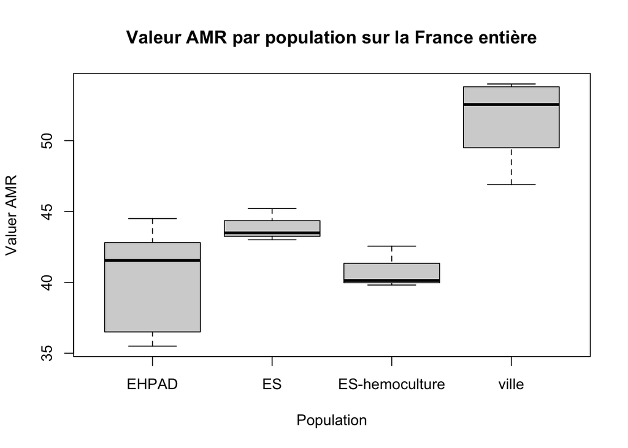

```r
boxplot(AMR_humaine_fr$`valeur AMR`~AMR_humaine_fr$population,
        main = "Valeur AMR par population sur la France entière",
        ylab = "Valuer AMR",
        xlab = "Population")
```

Valeurs de l’AMR plus élevées en ville qu’en EHPAD et Etablissements de santé –> l’AMR mesure bien la sensibilité des bactéries aux antibiotiques (et pas la résistance).

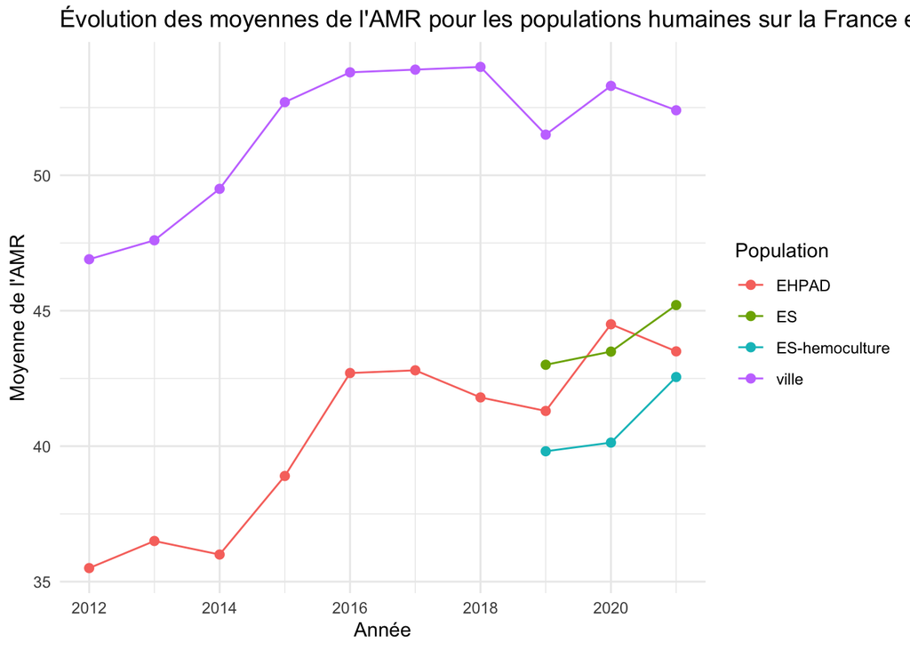

```r
ggplot(AMR_humaine_fr, aes(x = annee, y = `valeur AMR`, group = population, color = population)) +
  geom_line(stat = "summary", fun = "mean") +
  geom_point(stat = "summary", fun = "mean", size = 2) +
  labs(title = "Évolution des moyennes de l'AMR pour les populations humaines sur la France entière",
       x = "Année",
       y = "Moyenne de l'AMR",
       color = "Population") +
  theme_minimal()
```